# Can Gradient Boosting Predict Stock Returns?

- Show All Code
- Hide All Code
- View Source

From a classroom simulation to an honest out-of-sample market test

machine learning

stocks

gradient boosting

A chronological test of gradient boosting, richer predictors, and investment performance after trading costs.

Author

Manshu

Published

November 16, 2026

## What carries over from class?

Can a model that learns nonlinear patterns turn yesterday’s information into profitable stock forecasts? Class 21 provides a useful starting point: gradient boosting begins with the training mean, fits a shallow tree to residuals, and repeatedly adds a fraction of that correction:

$$F_m(x)=F_{m-1}(x)+\eta h_m(x).$$

The supplied lesson uses 1,200 **simulated** observations with five predictors; only two determine the outcome. Reproducing its 75/25 random split, seed 6400, and scikit-learn model gives test MSE 2.71, versus 8.68 for the training mean. Boosting can recover planted nonlinear structure.

**Scope:** the supplied lesson contains no stock dataset or stock experiment. This post extends its model settings to market data; it does not claim to reproduce an unavailable classroom stock backtest. The “class-settings baseline” below is therefore a new application of the lesson’s algorithm.

## A harder, real-data question

I predict FTSE index returns using R’s `EuStockMarkets`: 1,860 business-time observations of four European indices from 1991–1998, supplied by Erste Bank. This is a historical stock-index exercise, not a current-market forecast. The file has observation order rather than exact daily dates.

The baseline uses five recent FTSE returns and the lesson’s settings: 300 trees, learning rate 0.05, depth 2, and minimum leaf size 5. The proposed improvement adds 5- and 20-observation momentum and volatility for all four markets, plus other markets’ latest returns. These variables might capture persistent trends, changing risk, and shared market conditions.

Information ends at close $t$. To avoid assuming an immediate trade at that same close, execution is delayed to close $t+1$, and the target is:

$$y_t=\frac{P_{t+2}}{P_{t+1}}-1.$$

I divide usable rows chronologically into approximately 60% training, 20% validation, and 20% test. Two rows are purged before each later block so earlier labels cannot overlap its information dates. Sixteen conservative configurations vary tree count, learning rate, depth, and leaf size. Validation MSE selects the model; test outcomes never select features, settings, or trading rules. Both boosting models are then refitted on the same pre-test data.

**Show reproducible code**

```r
knitr::kable(splits, col.names = c("Stage", "Rows", "First feature obs.", "Last feature obs.", "Last target obs."))
```

| Stage | Rows | First feature obs. | Last feature obs. | Last target obs. |
| --- | --- | --- | --- | --- |
| Training | 1100 | 21 | 1120 | 1122 |
| Validation | 366 | 1123 | 1488 | 1490 |
| Final refit | 1468 | 21 | 1488 | 1490 |
| Test | 368 | 1491 | 1858 | 1860 |

## Does the improvement work?

Validation selects 50 trees, learning rate 0.01, depth 1, and leaf size 20. The learning curve illustrates the danger: improving training fit need not improve future performance.

**Show reproducible code**

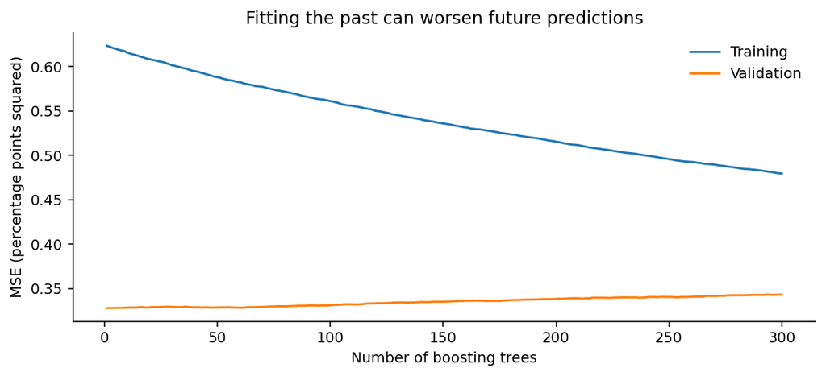

Figure 1: Class-settings model fitted only on the training block. Validation errors are evaluated separately; neither line uses the test block.

```r
knitr::include_graphics("results/figures/learning_curve.png")
```

On 368 held-out observations, baseline RMSE is 1.022 percentage points; the tuned model reaches 0.996. That is an improvement over the original settings, but the historical-mean benchmark achieves 0.990. Negative out-of-sample $R^2$, measured against that fixed pre-test mean, means boosting still loses to the simple forecast.

**Show reproducible code**

```r
display <- data.frame(Model = metrics$model,
  `RMSE (pp)` = round(100 * metrics$rmse, 3),
  `MAE (pp)` = round(100 * metrics$mae, 3),
  `Direction correct` = pct(metrics$directional_accuracy),
  `R2 vs mean` = round(metrics$r2_vs_historical_mean, 4), check.names = FALSE)
knitr::kable(display)
```

| Model | RMSE (pp) | MAE (pp) | Direction correct | R2 vs mean |
| --- | --- | --- | --- | --- |
| Historical mean | 0.990 | 0.761 | 52.17% | 0.0000 |
| Class-settings baseline | 1.022 | 0.782 | 52.99% | -0.0660 |
| Tuned richer model | 0.996 | 0.769 | 52.17% | -0.0133 |

**Show reproducible code**

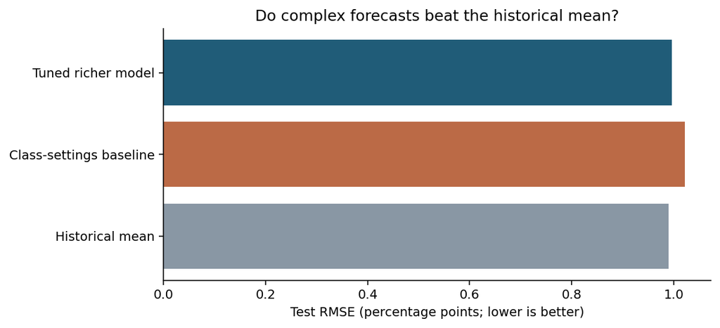

Figure 2: All forecasts face the same untouched test observations. Lower prediction error is better.

```r
knitr::include_graphics("results/figures/test_rmse.png")
```

Stock returns are difficult because news produces large unpredictable movements, conditional mean signals are weak, and relationships can change. A flexible model can learn historical noise. The simulation guarantees stable signal; market data offer no such guarantee.

## Would the predictions make money?

The fixed rule holds the index when predicted returns are positive and otherwise holds zero-interest cash. Each unit of one-way turnover costs 10 basis points, including entry and final liquidation. Buy-and-hold uses the same entry/exit costs.

**Show reproducible code**

```r
display <- data.frame(Strategy = investment$strategy,
  `Gross return` = pct(investment$gross_total_return),
  `Net return` = pct(investment$total_return),
  `Max drawdown` = pct(investment$max_drawdown),
  `Time invested` = pct(investment$exposure),
  `One-way turnover` = investment$one_way_turnover, check.names = FALSE)
knitr::kable(display)
```

| Strategy | Gross return | Net return | Max drawdown | Time invested | One-way turnover |
| --- | --- | --- | --- | --- | --- |
| Historical mean | 25.21% | 24.96% | -12.62% | 100.00% | 2 |
| Class-settings baseline | 26.58% | 5.95% | -13.21% | 60.60% | 178 |
| Tuned richer model | 25.21% | 24.96% | -12.62% | 100.00% | 2 |
| Buy and hold | 25.21% | 24.96% | -12.62% | 100.00% | 2 |

**Show reproducible code**

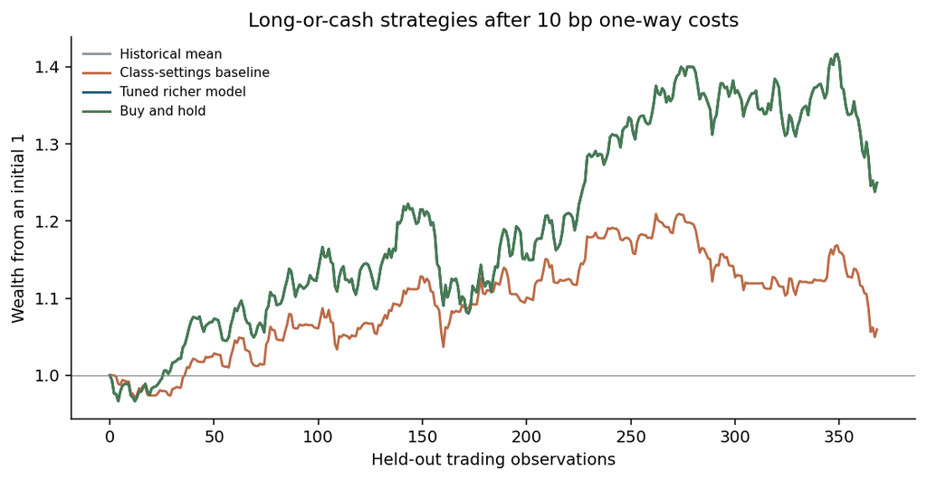

Figure 3: Net wealth on the identical held-out period. The historical-mean, tuned-model, and buy-and-hold curves overlap because all remain invested throughout.

```r
knitr::include_graphics("results/figures/net_wealth.png")
```

The baseline earns 5.95% net, despite 26.58% gross, because frequent switching is expensive. The tuned model earns 24.96%, exactly matching buy-and-hold: every test prediction is positive. Its gain reflects market exposure, not successful timing. Similar direction accuracy therefore need not imply similar investment outcomes.

These are illustrative index-return calculations. Indices are not directly tradable; fund tracking, dividends, taxes, actual cash interest, and execution prices are omitted. One old test window cannot establish reliable investment skill.

**Takeaway:** regularization and richer information improve this boosting baseline, yet fail to beat the historical mean in prediction or buy-and-hold economically. A more honest evaluation is a stronger result than a more complicated model.

## Sources and reproducibility

- Yisroel Cahn, *Class 21 — Decision Trees, Random Forests, and Gradient Boosting*, supplied course `.qmd`, sections 3–4 and 50. The simulation is reproduced; the stock application is new.
- [R documentation: EuStockMarkets](https://stat.ethz.ch/R-manual/R-devel/library/datasets/html/EuStockMarkets.html).
- [scikit-learn: GradientBoostingRegressor](https://scikit-learn.org/stable/modules/generated/sklearn.ensemble.GradientBoostingRegressor.html).

All calculations regenerate when this page renders. The repository folder includes raw data, the complete analysis, validation results, individual test forecasts, trading positions, cost sensitivity, and software versions. README.md explains installation and website integration.

**Show the full Python analysis**

```python
"""Chronological stock-index prediction experiment. Run from any directory."""
from pathlib import Path
import os
import tempfile
os.environ.setdefault("MPLCONFIGDIR", str(Path(tempfile.gettempdir()) / "post9_matplotlib"))
import json
import platform
import numpy as np
import pandas as pd
import sklearn
import matplotlib
matplotlib.use("Agg")
import matplotlib.pyplot as plt
from sklearn.ensemble import GradientBoostingRegressor
from sklearn.metrics import mean_squared_error, mean_absolute_error
from sklearn.model_selection import train_test_split, ParameterGrid

ROOT = Path(__file__).resolve().parents[1]
OUT = ROOT / "results"
FIG = OUT / "figures"
FIG.mkdir(parents=True, exist_ok=True)
plt.rcParams.update({"figure.dpi": 140, "axes.spines.top": False,
                     "axes.spines.right": False, "font.size": 10})
SEED = 6400
CLASS_PARAMS = dict(n_estimators=300, learning_rate=0.05, max_depth=2,
                    min_samples_leaf=5, random_state=SEED)

def savefig(name):
    plt.tight_layout()
    plt.savefig(FIG / name, bbox_inches="tight")
    plt.close()

def reproduce_class_simulation():
    # Class 21 sections 3-4 and 50, with the same random-number generator.
    rng = np.random.default_rng(SEED)
    x = rng.normal(size=(1200, 5))
    y = (3 + 2*x[:, 0] - 4*(x[:, 0] > 0) + 3*(x[:, 1] > 1)
         + 2*x[:, 0]*x[:, 1] + rng.normal(scale=1.5, size=1200))
    xt, xv, yt, yv = train_test_split(x, y, test_size=0.25, random_state=SEED)
    model = GradientBoostingRegressor(**CLASS_PARAMS).fit(xt, yt)
    pred = model.predict(xv)
    rows = [{"model": "Training mean", "test_mse": mean_squared_error(yv, np.full(len(yv), yt.mean()))},
            {"model": "Class 21 boosting", "test_mse": mean_squared_error(yv, pred)}]
    pd.DataFrame(rows).to_csv(OUT / "class_simulation.csv", index=False)
    return rows

def make_data():
    prices = pd.read_csv(ROOT / "data/european_indices.csv")
    assert len(prices) == 1860 and prices.observation.is_unique
    markets = ["DAX", "SMI", "CAC", "FTSE"]
    assert prices[markets].gt(0).all().all()
    # Ordinary fractional returns. No fabricated calendar dates.
    ret = prices[markets].pct_change(fill_method=None)
    d = pd.DataFrame({"feature_observation": prices.observation})
    # Information through close t; execution at close t+1; return t+1 -> t+2.
    d["target_observation"] = prices.observation.shift(-2)
    d["target"] = ret.FTSE.shift(-2)
    basic = []
    for lag in range(5):
        name = f"FTSE_lag{lag}"
        d[name] = ret.FTSE.shift(lag)
        basic.append(name)
    richer = basic.copy()
    for market in markets:
        for window in [5, 20]:
            mom = f"{market}_momentum{window}"
            vol = f"{market}_volatility{window}"
            d[mom] = prices[market].pct_change(window, fill_method=None)
            d[vol] = ret[market].rolling(window).std()
            richer += [mom, vol]
        if market != "FTSE":
            name = f"{market}_return"
            d[name] = ret[market]
            richer.append(name)
    d = d.dropna().reset_index(drop=True)
    assert np.isfinite(d.to_numpy()).all()
    return prices, d, basic, richer

def investment_metrics(returns):
    wealth = np.r_[1., np.cumprod(1 + returns)]
    vol = np.std(returns, ddof=1)
    return dict(total_return=wealth[-1]-1,
                annualized_return=wealth[-1]**(252/len(returns))-1,
                annualized_volatility=vol*np.sqrt(252),
                sharpe_zero_cash=np.mean(returns)/vol*np.sqrt(252) if vol > 0 else 0.,
                max_drawdown=np.min(wealth/np.maximum.accumulate(wealth)-1))

def main():
    class_results = reproduce_class_simulation()
    prices, d, basic, richer = make_data()
    n = len(d)
    a, b = int(n*.6), int(n*.8)
    train, valid, test = d.iloc[:a-2], d.iloc[a:b-2], d.iloc[b:]
    # Purge the last two feature rows at each boundary, including refitting.
    fit = d.iloc[:b-2]
    assert train.target_observation.max() < valid.feature_observation.min()
    assert fit.target_observation.max() < test.feature_observation.min()
    grid = ParameterGrid(dict(n_estimators=[50, 150], learning_rate=[.01, .03],
                             max_depth=[1, 2], min_samples_leaf=[20, 50]))
    tuning = []
    for params in grid:
        m = GradientBoostingRegressor(**params, random_state=SEED).fit(train[richer], train.target)
        tuning.append({**params, "validation_mse": mean_squared_error(valid.target, m.predict(valid[richer]))})
    tuning = pd.DataFrame(tuning).sort_values("validation_mse", kind="stable")
    tuning.to_csv(OUT / "validation_search.csv", index=False)
    best = tuning.iloc[0]
    params = {k: int(best[k]) for k in ["n_estimators", "max_depth", "min_samples_leaf"]}
    params["learning_rate"] = float(best.learning_rate)
    models = {"Class-settings baseline": GradientBoostingRegressor(**CLASS_PARAMS).fit(fit[basic], fit.target),
              "Tuned richer model": GradientBoostingRegressor(**params, random_state=SEED).fit(fit[richer], fit.target)}
    predictions = {"Historical mean": np.full(len(test), fit.target.mean()),
                   "Class-settings baseline": models["Class-settings baseline"].predict(test[basic]),
                   "Tuned richer model": models["Tuned richer model"].predict(test[richer])}
    y = test.target.to_numpy()
    denom = np.sum((y-fit.target.mean())**2)
    metrics, strategies, equity = [], [], {}
    prediction_output = test[["feature_observation", "target_observation", "target"]].copy()
    position_output = prediction_output.copy()
    cost = .001  # 10 basis points per unit one-way turnover, fixed before testing.
    for name, p in predictions.items():
        metrics.append(dict(model=name, rmse=np.sqrt(mean_squared_error(y, p)),
                            mae=mean_absolute_error(y, p),
                            directional_accuracy=np.mean((p > 0) == (y > 0)),
                            r2_vs_historical_mean=1-np.sum((y-p)**2)/denom))
        prediction_output[name] = p
    for name, p in {**predictions, "Buy and hold": np.ones(len(y))}.items():
        position = (p > 0).astype(float)
        turnover = np.abs(np.diff(np.r_[0., position]))
        # Charge liquidation on the final observation as well.
        turnover[-1] += position[-1]
        gross = position*y
        net = gross-cost*turnover
        strategies.append(dict(strategy=name, **investment_metrics(net),
                               gross_total_return=np.prod(1+gross)-1,
                               exposure=position.mean(), one_way_turnover=turnover.sum()))
        equity[name] = np.cumprod(1+net)
        position_output[name+"_position"] = position
        position_output[name+"_net_return"] = net
    metrics = pd.DataFrame(metrics)
    strategies = pd.DataFrame(strategies)
    metrics.to_csv(OUT / "predictive_metrics.csv", index=False)
    strategies.to_csv(OUT / "investment_metrics.csv", index=False)
    prediction_output.to_csv(OUT / "test_predictions.csv", index=False)
    position_output.to_csv(OUT / "test_positions_and_returns.csv", index=False)
    d.to_csv(OUT / "features.csv", index=False)
    split_rows = []
    for name, frame in [("Training", train), ("Validation", valid), ("Final refit", fit), ("Test", test)]:
        split_rows.append(dict(split=name, rows=len(frame),
                               feature_start=int(frame.feature_observation.min()),
                               feature_end=int(frame.feature_observation.max()),
                               target_end=int(frame.target_observation.max())))
    pd.DataFrame(split_rows).to_csv(OUT / "splits.csv", index=False)
    # Training vs validation loss by boosting stage; test data never select a stage.
    original = GradientBoostingRegressor(**CLASS_PARAMS).fit(train[basic], train.target)
    learning = pd.DataFrame({"trees": np.arange(1, 301),
                            "train_mse": [mean_squared_error(train.target, p) for p in original.staged_predict(train[basic])],
                            "validation_mse": [mean_squared_error(valid.target, p) for p in original.staged_predict(valid[basic])]})
    learning.to_csv(OUT / "learning_curve.csv", index=False)
    fig, ax = plt.subplots(figsize=(8, 3.7))
    for col, label in [("train_mse", "Training"), ("validation_mse", "Validation")]:
        ax.plot(learning.trees, learning[col]*1e4, label=label)
    ax.set(xlabel="Number of boosting trees", ylabel="MSE (percentage points squared)", title="Fitting the past can worsen future predictions")
    ax.legend(frameon=False)
    savefig("learning_curve.png")
    fig, ax = plt.subplots(figsize=(8, 3.7))
    ax.barh(metrics.model, metrics.rmse*100, color=["#8997a4", "#bb6a46", "#205c78"])
    ax.set(xlabel="Test RMSE (percentage points; lower is better)", title="Do complex forecasts beat the historical mean?")
    savefig("test_rmse.png")
    fig, ax = plt.subplots(figsize=(8, 4.2))
    colors = ["#8997a4", "#bb6a46", "#205c78", "#477b50"]
    for (name, wealth), color in zip(equity.items(), colors):
        ax.plot(np.arange(len(y)+1), np.r_[1., wealth], label=name, color=color)
    ax.axhline(1, color="gray", lw=.6)
    ax.set(xlabel="Held-out trading observations", ylabel="Wealth from an initial 1", title="Long-or-cash strategies after 10 bp one-way costs")
    ax.legend(frameon=False, fontsize=8)
    savefig("net_wealth.png")
    sensitivity = []
    p = (predictions["Tuned richer model"] > 0).astype(float)
    turn = np.abs(np.diff(np.r_[0., p])); turn[-1] += p[-1]
    for bp in [0, 5, 10, 25]:
        sensitivity.append(dict(cost_bp=bp, **investment_metrics(p*y-bp/10000*turn)))
    pd.DataFrame(sensitivity).to_csv(OUT / "cost_sensitivity.csv", index=False)
    summary = dict(selected_parameters=params, baseline_parameters=CLASS_PARAMS,
                   n_observations=n, test_observations=len(test),
                   simple_features=basic, richer_features=richer,
                   class_simulation=class_results,
                   versions=dict(python=platform.python_version(), sklearn=sklearn.__version__,
                                 numpy=np.__version__, pandas=pd.__version__, matplotlib=matplotlib.__version__),
                   data_period="1991-1998; observation order only; no daily calendar dates provided",
                   trading_rule="Signal through t; execution t+1 close; return t+1 to t+2; long iff forecast > 0",
                   cash_return=0, cost_basis_points=10)
    (OUT / "summary.json").write_text(json.dumps(summary, indent=2)+"\n")
    print(metrics.to_string(index=False))
    print(strategies.to_string(index=False))
    print("Selected:", params)

if __name__ == "__main__":
    main()
```